# Pilot 3: model-free behavioral analysis (main analyses)

# 0. Setup

## 0.1 Packages

```r
library(dplyr)
```

```r
library(tidyr)
library(ggplot2)
library(patchwork)
library(lme4)
library(lmerTest)
library(emmeans)
```

## 0.2 Input file, output folder and analysis settings

```r
# merged raw data of everyone who performed the task (path relative to this Rmd)
raw_data_file <- "../main_data/filtered_data/all_action_only_approved_awaiting_with_demo.csv"

# all output of this file (figures, exclusion summary) is written here
output_dir <- "figures"
dir.create(output_dir, showWarnings = FALSE, recursive = TRUE)

# exclusion criteria (identical in the full analysis file)
omission_cutoff    <- 13    # excluded if prediction omissions > 13 OR choice omissions > 13
attention_required <- 1     # excluded if attention-check accuracy < 1 (any attention item answered wrongly)
chance_level       <- 0.5   # excluded if mean choice accuracy across blocks <= 0.5

# demonstrator accuracy (%) = number of trials on which the demonstrator chose the high-probability image / 11
n_demo_trials_per_block <- 11
```

## 0.3 Figure style

```r
theme_set(
  theme_classic(base_size = 10, base_family = "sans") +
    theme(axis.text        = element_text(colour = "black"),
          axis.line        = element_line(colour = "black", linewidth = 0.4),
          axis.ticks       = element_line(colour = "black", linewidth = 0.4),
          strip.background = element_blank(),
          legend.key.size  = unit(0.4, "cm"),
          legend.position  = "top",
          plot.title       = element_text(size = 10, face = "bold", hjust = 0),
          plot.tag         = element_text(face = "bold", size = 12))
)

colour_grouping <- c("in" = "#2B6CC4", "out" = "#E03C31")
colour_iq       <- c("high" = "#009E73", "low" = "#CC79A7")
label_grouping  <- c("in" = "In-group", "out" = "Out-group")
label_iq        <- c("high" = "High IQ", "low" = "Low IQ")
```

# 1. Data import and preprocessing (all participants)

The raw file is read once. Every participant goes through the same preprocessing. Exclusion criteria are then applied, and included participants are selected from the already-preprocessed data

## 1.1 Raw data

```r
raw_data <- read.csv(raw_data_file, colClasses = c(participant = "character")) %>%
  mutate(across(where(is.character), ~ na_if(.x, "")))     # empty cells -> NA

cat(n_distinct(raw_data$participant), "participants before exclusion")
```

```
## 89 participants before exclusion
```

## 1.2 Fill block-level information within participant

```r
preprocessed_data <- raw_data %>%
  group_by(participant) %>%
  fill(phase, condition, demo_img, demo_iq, .direction = "down") %>%
  fill(perf_expectation_post, performance_rating.started, performance_rating.stopped, .direction = "up") %>%
  ungroup()
```

## 1.3 Main-phase data

```r
all_main_phase_data <- preprocessed_data %>%
  filter(phase == "main") %>%
  mutate(grouping = factor(case_when(grepl("^in", condition)  ~ "in",
                                     grepl("^out", condition) ~ "out"),
                           levels = c("in", "out")),
         iq       = factor(case_when(grepl("high", condition) ~ "high",
                                     grepl("low", condition)  ~ "low"),
                           levels = c("high", "low")))
```

## 1.4 Demonstrator accuracy per block

```r
block_demo_accuracy <- all_main_phase_data %>%
  filter(!is.na(demo_img)) %>%
  group_by(participant, condition, demo_img) %>%
  summarise(demo_accuracy = round(100 * sum(demo_result == "correct", na.rm = TRUE) / n_demo_trials_per_block),
            .groups = "drop")
```

## 1.5 Trial-level data (all participants)

One row per trial. Outcome variables:

- `choice_correct`: the participant chose the high-probability option (`dec_side == dec_pos`); NA if the choice was omitted.
- `pred_correct`: the participant’s prediction matched the demonstrator’s actual choice (`pred_side == demo_chosen_side`); NA if the prediction was omitted.
- `choice_rt`, `pred_rt`: response times in ms.
- `participant_chose_highprob`, `demo_chose_highprob`, `imitated`, `demo_correct`, `pred_chose_highprob`: imitation variables (used in the full analysis file).

`trial_c` is added only after exclusion (section 3), because it is centred on the included trials.

```r
all_trial_data <- all_main_phase_data %>%
  filter(!is.na(trial_num)) %>%
  mutate(choice_correct             = as.integer(dec_side == dec_pos),
         pred_correct               = as.integer(pred_side == demo_chosen_side),
         choice_rt                  = dec_resp_rt * 1000,
         pred_rt                    = obs_resp_rt * 1000,
         participant_chose_highprob = chosen_image == high_prob_image,
         demo_chose_highprob        = demo_chosen_side == obs_pos,
         imitated                   = as.integer(participant_chose_highprob == demo_chose_highprob),
         demo_correct               = as.integer(demo_chose_highprob),
         pred_chose_highprob        = as.integer(pred_side == obs_pos)) %>%
  left_join(block_demo_accuracy, by = c("participant", "condition", "demo_img"))

cat(n_distinct(all_trial_data$participant), "participants with main-phase trials,",
    nrow(all_trial_data), "trials\n")
```

```
## 89 participants with main-phase trials, 11748 trials
```

# 2. Quality checks and exclusion criteria

## 2.1 Participant-level quality measures

```r
# omissions (missing responses) across all main-phase trials
participant_omissions <- all_trial_data %>%
  group_by(participant) %>%
  summarise(n_trials        = n(),
            pred_omission   = sum(is.na(pred_side)),
            choice_omission = sum(is.na(dec_side)),
            .groups = "drop")

# attention checks
participant_attention <- raw_data %>%
  filter(!is.na(attn_correct)) %>%
  group_by(participant) %>%
  summarise(attn_accuracy = mean(attn_correct, na.rm = TRUE),
            attn_mean_rt  = mean(attn_rt, na.rm = TRUE),
            .groups = "drop")

# learning performance: choice accuracy per block (participant x demonstrator), using trials with a valid choice
block_choice_accuracy <- all_trial_data %>%
  filter(!is.na(choice_correct)) %>%
  group_by(participant, condition, demo_img) %>%
  summarise(block_accuracy = mean(choice_correct), .groups = "drop")

# ... then averaged over all blocks of a participant
participant_block_accuracy <- block_choice_accuracy %>%
  group_by(participant) %>%
  summarise(n_blocks_with_choice = n(),
            mean_block_accuracy  = mean(block_accuracy),
            .groups = "drop")

participant_quality_check <- participant_omissions %>%
  left_join(participant_attention, by = "participant") %>%
  left_join(participant_block_accuracy, by = "participant")
```

## 2.2 Exclusion criteria

A participant is excluded if **any** of the following is true:

1. **Omission**: more than 13 predictions or choices.
2. **Attention**: attention-check accuracy below 1, i.e. at least one attention item answered wrongly.
3. **Learning**: mean choice accuracy over blocks at or below chance (0.5). Block accuracy is the proportion of high-probability choices among the trials with a valid choice in that block. The participant’s value is the mean over all blocks with at least one valid choice.

```r
participant_exclusion_summary <- participant_quality_check %>%
  mutate(excl_omission  = pred_omission > omission_cutoff | choice_omission > omission_cutoff,
         excl_attention = attn_accuracy < attention_required,
         excl_learning  = mean_block_accuracy <= chance_level,
         across(c(excl_omission, excl_attention, excl_learning), ~ coalesce(.x, TRUE)))

participants_without_trials <- setdiff(unique(raw_data$participant), participant_exclusion_summary$participant)

participant_exclusion_summary <- participant_exclusion_summary %>%
  bind_rows(tibble(participant = participants_without_trials)) %>%
  mutate(excluded = coalesce(excl_omission | excl_attention | excl_learning, FALSE)) %>%
  select(participant, n_trials, pred_omission, choice_omission, attn_accuracy,
         n_blocks_with_choice, mean_block_accuracy,
         excl_omission, excl_attention, excl_learning, excluded)

excluded_ids <- participant_exclusion_summary$participant[participant_exclusion_summary$excluded]
included_ids <- setdiff(unique(raw_data$participant), excluded_ids)

write.csv(participant_exclusion_summary, file.path(output_dir, "participant_exclusion_summary.csv"),
          row.names = FALSE, na = "")
```

## 2.3 Exclusion counts

The criterion counts can overlap, because one participant may meet several criteria.

```r
tibble(all_participants     = n_distinct(raw_data$participant),
       excluded             = length(excluded_ids),
       included             = length(included_ids),
       omission   = sum(participant_exclusion_summary$excl_omission, na.rm = TRUE),
       attention  = sum(participant_exclusion_summary$excl_attention, na.rm = TRUE),
       learning   = sum(participant_exclusion_summary$excl_learning, na.rm = TRUE))
```

```
## # A tibble: 1 x 6
##   all_participants excluded included omission attention learning
##              <int>    <int>    <int>    <int>     <int>    <int>
## 1               89       27       62        9        17        7
```

```r
# excluded participants and the criteria they met
participant_exclusion_summary %>%
  filter(excluded) %>%
  mutate(across(c(attn_accuracy, mean_block_accuracy), ~ round(.x, 3)))
```

```
## # A tibble: 27 x 11
##    participant              n_trials pred_omission choice_omission attn_accuracy
##    <chr>                       <int>         <int>           <int>         <dbl>
##  1 5addd5e8a7f2df000154665b      132             1               2          0.75
##  2 5dd3e3cd5daaa63c5fdb7bb8      132           132               0          1
##  3 5f5967d6e280e61b2db8e55c      132           132               5          1
##  4 5fd67cce91f9895969c0edee      132             4               5          0.75
##  5 664de00831e4cbd893d0e90e      132             0               0          0.75
##  6 66932b8c2bd15cf7a058c3f7      132           131               1          1
##  7 677f3c406e5c69e32cf8efc5      132             0               0          0.75
##  8 69602ae6ebc51ed9c9cadbe5      132             3               4          0.75
##  9 69791b44e5a5e7384d41eeb4      132             0               3          1
## 10 698346c67046f0f9d655f5f5      132           132               0          1
## # i 17 more rows
## # i 6 more variables: n_blocks_with_choice <int>, mean_block_accuracy <dbl>,
## #   excl_omission <lgl>, excl_attention <lgl>, excl_learning <lgl>,
## #   excluded <lgl>
```

# 3. Analysis data (included participants only)

Included participants are selected from the preprocessed data. The raw file is not read a second time.

**Naming rule.** Objects that start with `all_` contain every participant and are used only for preprocessing and the exclusion criteria (sections 1–2). From this section on, objects without the prefix contain **included participants only**:

- `main_phase_data`: main-phase rows
- `trial_data`: one row per trial
- `demonstrator_data`: one row per participant × demonstrator (block)

```r
main_phase_data <- all_main_phase_data %>%
  filter(participant %in% included_ids)

trial_data <- all_trial_data %>%
  filter(participant %in% included_ids) %>%
  mutate(trial_c = trial_num - mean(trial_num))     # centered trial number (included trials)

# one row per participant x demonstrator (block): ratings and demonstrator accuracy
demonstrator_ratings <- main_phase_data %>%
  filter(!is.na(demo_img)) %>%
  group_by(participant, condition, grouping, iq, demo_img) %>%
  summarise(across(c(closeness_rating, perf_expectation_pre, perf_expectation_post, demo_iq),
                   ~ first(.x[!is.na(.x)])),
            .groups = "drop")

demonstrator_data <- demonstrator_ratings %>%
  left_join(block_demo_accuracy, by = c("participant", "condition", "demo_img"))

cat(n_distinct(trial_data$participant), "participants,", nrow(trial_data), "trials")
```

```
## 62 participants, 8184 trials
```

# 4. Manipulation checks

## 4.1 Grouping manipulation: closeness rating, in-group vs. out-group

Each participant’s closeness ratings are averaged over the in-group and over the out-group demonstrators. Participants with both values are compared with a paired t-test.

```r
# participant-level data
closeness_wide <- demonstrator_data %>%
  group_by(participant, grouping) %>%
  summarise(closeness = mean(closeness_rating, na.rm = TRUE), .groups = "drop") %>%
  pivot_wider(names_from = grouping, values_from = closeness) %>%
  filter(!is.na(`in`), !is.na(out))

# statistical test
closeness_t_test <- t.test(closeness_wide$`in`, closeness_wide$out, paired = TRUE)
closeness_t_test
```

```
##
##  Paired t-test
##
## data:  closeness_wide$`in` and closeness_wide$out
## t = 17.125, df = 61, p-value < 2.2e-16
## alternative hypothesis: true mean difference is not equal to 0
## 95 percent confidence interval:
##  50.22918 63.50988
## sample estimates:
## mean difference
##        56.86953
```

```r
# descriptive statistics and effect size (paired Cohen's d_z = mean difference / SD of differences)
closeness_difference <- closeness_wide$`in` - closeness_wide$out
tibble(n              = nrow(closeness_wide),
       mean_in        = mean(closeness_wide$`in`),
       sd_in          = sd(closeness_wide$`in`),
       mean_out       = mean(closeness_wide$out),
       sd_out         = sd(closeness_wide$out),
       mean_diff      = mean(closeness_difference),
       ci_diff_low    = closeness_t_test$conf.int[1],
       ci_diff_high   = closeness_t_test$conf.int[2],
       t              = unname(closeness_t_test$statistic),
       df             = unname(closeness_t_test$parameter),
       p_t            = closeness_t_test$p.value,
       cohens_dz      = mean(closeness_difference) / sd(closeness_difference)) %>%
  mutate(p_t = scales::pvalue(p_t, accuracy = 0.001), across(where(is.numeric), ~ round(.x, 3)))
```

```
## # A tibble: 1 x 12
##       n mean_in sd_in mean_out sd_out mean_diff ci_diff_low ci_diff_high     t
##   <dbl>   <dbl> <dbl>    <dbl>  <dbl>     <dbl>       <dbl>        <dbl> <dbl>
## 1    62    74.4  20.1     17.5   13.9      56.9        50.2         63.5  17.1
## # i 3 more variables: df <dbl>, p_t <chr>, cohens_dz <dbl>
```

```r
# figure data: one point per participant per condition; fixed horizontal jitter per participant so paired lines stay straight
set.seed(1)
closeness_jitter <- tibble(participant = closeness_wide$participant,
                           jitter      = runif(nrow(closeness_wide), -0.06, 0.06))

closeness_plot_data <- closeness_wide %>%
  pivot_longer(c(`in`, out), names_to = "grouping", values_to = "closeness") %>%
  left_join(closeness_jitter, by = "participant") %>%
  mutate(grouping = factor(grouping, levels = c("in", "out")),
         x_point  = as.numeric(grouping) + jitter)

closeness_plot_summary <- closeness_plot_data %>%
  group_by(grouping) %>%
  summarise(n = n(), mean = mean(closeness), sd = sd(closeness), .groups = "drop") %>%
  mutate(ci_half = qt(0.975, n - 1) * sd / sqrt(n),
         x_mean  = as.numeric(grouping) + c(-0.25, 0.25))

closeness_range <- diff(range(closeness_plot_data$closeness))
closeness_significance <- tibble(p = closeness_t_test$p.value,
                                 y = max(closeness_plot_data$closeness) + 0.08 * closeness_range) %>%
  filter(p < .05) %>%
  mutate(label = case_when(p < .001 ~ "***", p < .01 ~ "**", TRUE ~ "*"))

fig_closeness <- ggplot(closeness_plot_data, aes(x = x_point, y = closeness)) +
  geom_line(aes(group = participant), colour = "grey75", linewidth = 0.3) +
  geom_point(aes(colour = grouping), size = 1.4, alpha = 0.6) +
  geom_errorbar(data = closeness_plot_summary, aes(x = x_mean, ymin = mean - ci_half, ymax = mean + ci_half),
                inherit.aes = FALSE, width = 0.08, linewidth = 0.6) +
  geom_point(data = closeness_plot_summary, aes(x = x_mean, y = mean, fill = grouping),
             inherit.aes = FALSE, shape = 21, size = 3, colour = "black") +
  geom_segment(data = closeness_significance, aes(x = 1, xend = 2, y = y, yend = y), inherit.aes = FALSE, linewidth = 0.4) +
  geom_text(data = closeness_significance, aes(x = 1.5, y = y, label = label), inherit.aes = FALSE, vjust = -0.2, size = 4) +
  scale_x_continuous(breaks = 1:2, labels = label_grouping[c("in", "out")], expand = expansion(add = 0.45)) +
  scale_colour_manual(values = colour_grouping, guide = "none") +
  scale_fill_manual(values = colour_grouping, guide = "none") +
  scale_y_continuous(expand = expansion(mult = c(0.05, 0.15))) +
  labs(x = "Demonstrator group", y = "Closeness rating")
```

## 4.2 IQ manipulation: expected performance before learning, high vs. low IQ

The pre-block performance expectation (`perf_expectation_pre`) is averaged over the high-IQ and over the low-IQ demonstrators of each participant.

```r
expectation_pre_wide <- demonstrator_data %>%
  group_by(participant, iq) %>%
  summarise(expectation_pre = mean(perf_expectation_pre, na.rm = TRUE), .groups = "drop") %>%
  pivot_wider(names_from = iq, values_from = expectation_pre) %>%
  filter(!is.na(high), !is.na(low))

expectation_pre_t_test <- t.test(expectation_pre_wide$high, expectation_pre_wide$low, paired = TRUE)
expectation_pre_t_test
```

```
##
##  Paired t-test
##
## data:  expectation_pre_wide$high and expectation_pre_wide$low
## t = 9.9836, df = 61, p-value = 1.899e-14
## alternative hypothesis: true mean difference is not equal to 0
## 95 percent confidence interval:
##  20.19323 30.30825
## sample estimates:
## mean difference
##        25.25074
```

```r
expectation_pre_difference <- expectation_pre_wide$high - expectation_pre_wide$low
tibble(n              = nrow(expectation_pre_wide),
       mean_high      = mean(expectation_pre_wide$high),
       sd_high        = sd(expectation_pre_wide$high),
       mean_low       = mean(expectation_pre_wide$low),
       sd_low         = sd(expectation_pre_wide$low),
       mean_diff      = mean(expectation_pre_difference),
       ci_diff_low    = expectation_pre_t_test$conf.int[1],
       ci_diff_high   = expectation_pre_t_test$conf.int[2],
       t              = unname(expectation_pre_t_test$statistic),
       df             = unname(expectation_pre_t_test$parameter),
       p_t            = expectation_pre_t_test$p.value,
       cohens_dz      = mean(expectation_pre_difference) / sd(expectation_pre_difference)) %>%
  mutate(p_t = scales::pvalue(p_t, accuracy = 0.001), across(where(is.numeric), ~ round(.x, 3)))
```

```
## # A tibble: 1 x 12
##       n mean_high sd_high mean_low sd_low mean_diff ci_diff_low ci_diff_high
##   <dbl>     <dbl>   <dbl>    <dbl>  <dbl>     <dbl>       <dbl>        <dbl>
## 1    62      72.3    14.0     47.1   14.7      25.3        20.2         30.3
## # i 4 more variables: t <dbl>, df <dbl>, p_t <chr>, cohens_dz <dbl>
```

```r
set.seed(1)
expectation_pre_jitter <- tibble(participant = expectation_pre_wide$participant,
                                 jitter      = runif(nrow(expectation_pre_wide), -0.06, 0.06))

expectation_pre_plot_data <- expectation_pre_wide %>%
  pivot_longer(c(high, low), names_to = "iq", values_to = "expectation_pre") %>%
  left_join(expectation_pre_jitter, by = "participant") %>%
  mutate(iq      = factor(iq, levels = c("high", "low")),
         x_point = as.numeric(iq) + jitter)

expectation_pre_plot_summary <- expectation_pre_plot_data %>%
  group_by(iq) %>%
  summarise(n = n(), mean = mean(expectation_pre), sd = sd(expectation_pre), .groups = "drop") %>%
  mutate(ci_half = qt(0.975, n - 1) * sd / sqrt(n),
         x_mean  = as.numeric(iq) + c(-0.25, 0.25))

expectation_pre_range <- diff(range(expectation_pre_plot_data$expectation_pre))
expectation_pre_significance <- tibble(p = expectation_pre_t_test$p.value,
                                       y = max(expectation_pre_plot_data$expectation_pre) + 0.08 * expectation_pre_range) %>%
  filter(p < .05) %>%
  mutate(label = case_when(p < .001 ~ "***", p < .01 ~ "**", TRUE ~ "*"))

fig_expectation_pre <- ggplot(expectation_pre_plot_data, aes(x = x_point, y = expectation_pre)) +
  geom_line(aes(group = participant), colour = "grey75", linewidth = 0.3) +
  geom_point(aes(colour = iq), size = 1.4, alpha = 0.6) +
  geom_errorbar(data = expectation_pre_plot_summary, aes(x = x_mean, ymin = mean - ci_half, ymax = mean + ci_half),
                inherit.aes = FALSE, width = 0.08, linewidth = 0.6) +
  geom_point(data = expectation_pre_plot_summary, aes(x = x_mean, y = mean, fill = iq),
             inherit.aes = FALSE, shape = 21, size = 3, colour = "black") +
  geom_segment(data = expectation_pre_significance, aes(x = 1, xend = 2, y = y, yend = y), inherit.aes = FALSE, linewidth = 0.4) +
  geom_text(data = expectation_pre_significance, aes(x = 1.5, y = y, label = label), inherit.aes = FALSE, vjust = -0.2, size = 4) +
  scale_x_continuous(breaks = 1:2, labels = label_iq[c("high", "low")], expand = expansion(add = 0.45)) +
  scale_colour_manual(values = colour_iq, guide = "none") +
  scale_fill_manual(values = colour_iq, guide = "none") +
  scale_y_continuous(expand = expansion(mult = c(0.05, 0.15))) +
  labs(x = "Demonstrator IQ", y = "Expected performance (pre)")
```

## 4.3 Figure: manipulation checks

Grey lines connect the two values of the same participant. Large points with error bars show the mean and 95% CI. Asterisks are shown only when the paired t-test is significant: * p < .05, ** p < .01, *** p < .001.

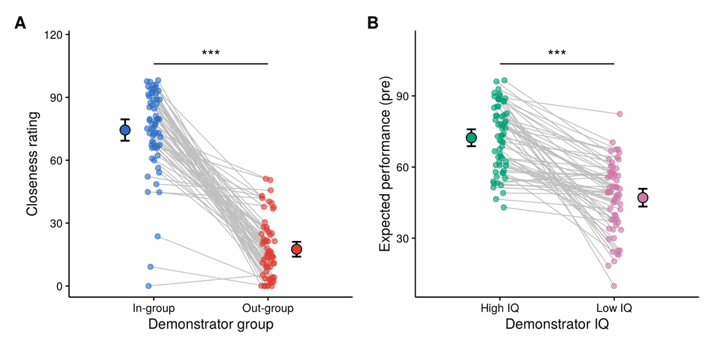

```r
fig_manipulation_checks <- (fig_closeness | fig_expectation_pre) + plot_annotation(tag_levels = "A")
fig_manipulation_checks
```

```r
ggsave(file.path(output_dir, "fig1_manipulation_checks.png"), fig_manipulation_checks,
       width = 140, height = 80, units = "mm", dpi = 300)
```

## 4.4 Expected performance (pre): interaction plot by condition

Each participant’s pre-block expected performance is averaged within each condition. The plot shows the mean of these participant values with ± 1 SEM error bars, in the same style as the choice interaction plot (section 9.2).

```r
expectation_condition_cells <- demonstrator_data %>%
  filter(!is.na(perf_expectation_pre)) %>%
  group_by(participant, grouping, iq) %>%
  summarise(expectation_pre = mean(perf_expectation_pre), .groups = "drop")

expectation_condition_summary <- expectation_condition_cells %>%
  group_by(grouping, iq) %>%
  summarise(n = n(), mean = mean(expectation_pre), sd = sd(expectation_pre), .groups = "drop") %>%
  mutate(sem = sd / sqrt(n))

expectation_condition_summary %>% mutate(across(where(is.numeric), ~ round(.x, 3)))
```

```
## # A tibble: 4 x 6
##   grouping iq        n  mean    sd   sem
##   <fct>    <fct> <dbl> <dbl> <dbl> <dbl>
## 1 in       high     62  77.1  14.6  1.85
## 2 in       low      62  53.5  16.7  2.12
## 3 out      high     62  67.6  16.3  2.07
## 4 out      low      62  40.6  15.9  2.02
```

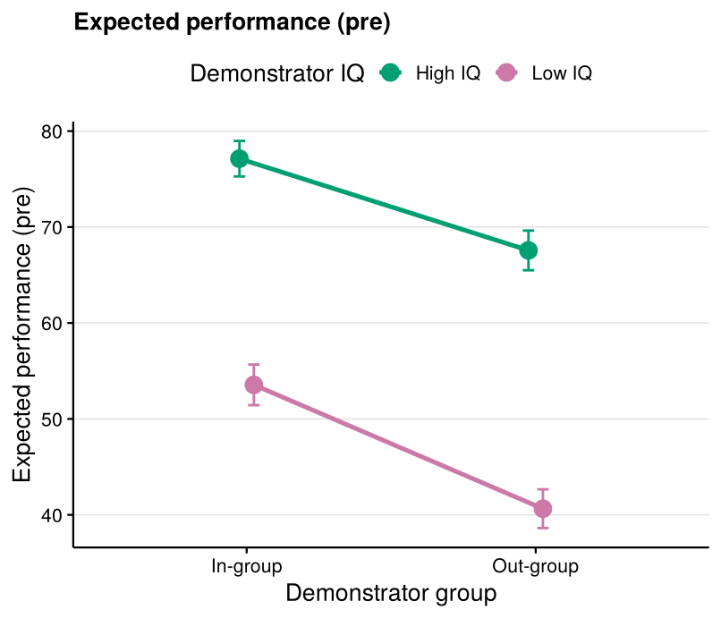

```r
fig_expectation_conditions <- ggplot(expectation_condition_summary, aes(x = grouping, y = mean, colour = iq, group = iq)) +
  geom_line(linewidth = 0.9, position = position_dodge(width = 0.1)) +
  geom_errorbar(aes(ymin = mean - sem, ymax = mean + sem), width = 0.08, linewidth = 0.5,
                position = position_dodge(width = 0.1)) +
  geom_point(size = 3, position = position_dodge(width = 0.1)) +
  scale_x_discrete(labels = label_grouping) +
  scale_colour_manual(values = colour_iq, labels = label_iq, name = "Demonstrator IQ") +
  labs(x = "Demonstrator group", y = "Expected performance (pre)", title = "Expected performance (pre)") +
  theme(panel.grid.major.y = element_line(colour = "grey90", linewidth = 0.3))

fig_expectation_conditions
```

```r
ggsave(file.path(output_dir, "expectation_conditions.png"), fig_expectation_conditions,
       width = 105, height = 90, units = "mm", dpi = 300)
```

## 4.5 Expected performance update by demonstrator accuracy

Expectation change = post-block expectation − pre-block expectation, computed for each block. `demo_accuracy` is the percentage of the 11 trials of a block on which the demonstrator chose the high-probability image. Each participant’s changes are averaged within each demonstrator-accuracy level. The figure uses the same design as the overall learning curve (section 6): small grey points are participants, and the black line and ribbon show the mean and 95% CI. The dashed line marks no change.

```r
expectation_update_participant <- demonstrator_data %>%
  filter(!is.na(perf_expectation_pre), !is.na(perf_expectation_post), !is.na(demo_accuracy)) %>%
  mutate(expectation_change = perf_expectation_post - perf_expectation_pre) %>%
  group_by(participant, demo_accuracy) %>%
  summarise(expectation_change = mean(expectation_change), .groups = "drop")

expectation_update_summary <- expectation_update_participant %>%
  group_by(demo_accuracy) %>%
  summarise(n = n(), mean = mean(expectation_change), sd = sd(expectation_change), .groups = "drop") %>%
  mutate(ci_low  = mean - qt(0.975, n - 1) * sd / sqrt(n),
         ci_high = mean + qt(0.975, n - 1) * sd / sqrt(n))

expectation_update_summary %>% mutate(across(where(is.numeric), ~ round(.x, 3)))
```

```
## # A tibble: 3 x 6
##   demo_accuracy     n   mean    sd ci_low ci_high
##           <dbl> <dbl>  <dbl> <dbl>  <dbl>   <dbl>
## 1            73    62 -0.129  9.94  -2.65    2.40
## 2            82    62  4.00   8.80   1.76    6.23
## 3            91    62  7.07   9.33   4.70    9.44
```

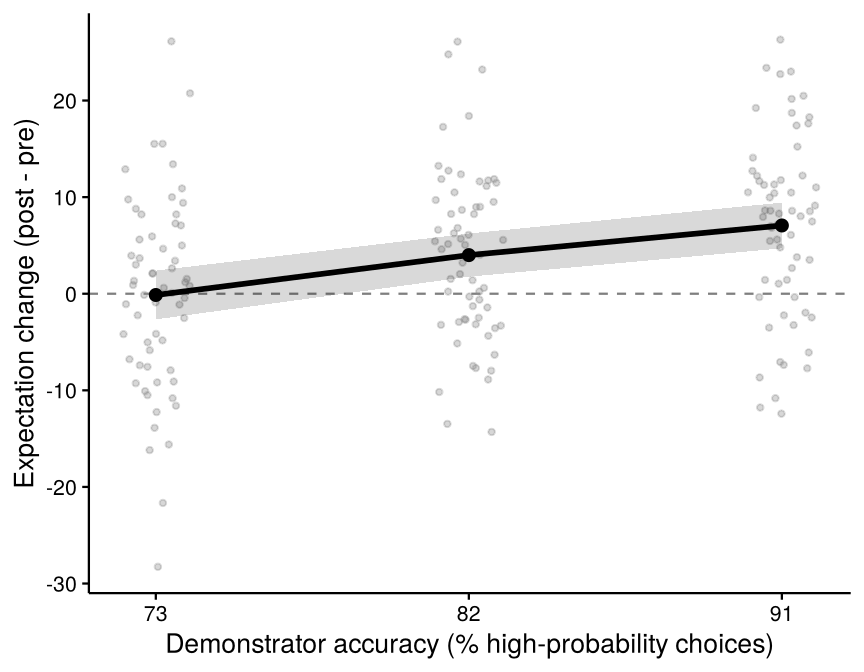

```r
fig_expectation_update <- ggplot(expectation_update_participant, aes(x = demo_accuracy, y = expectation_change)) +
  geom_hline(yintercept = 0, linetype = "dashed", colour = "grey50", linewidth = 0.4) +
  geom_point(position = position_jitter(width = 1, height = 0, seed = 1),
             colour = "grey55", alpha = 0.35, size = 0.8) +
  geom_ribbon(data = expectation_update_summary, aes(x = demo_accuracy, ymin = ci_low, ymax = ci_high),
              inherit.aes = FALSE, fill = "black", alpha = 0.15) +
  geom_line(data = expectation_update_summary, aes(x = demo_accuracy, y = mean), inherit.aes = FALSE, linewidth = 1) +
  geom_point(data = expectation_update_summary, aes(x = demo_accuracy, y = mean), inherit.aes = FALSE, size = 1.8) +
  scale_x_continuous(breaks = sort(unique(expectation_update_summary$demo_accuracy))) +
  labs(x = "Demonstrator accuracy (% high-probability choices)", y = "Expectation change (post - pre)")

fig_expectation_update
```

```r
ggsave(file.path(output_dir, "expectation_update.png"), fig_expectation_update,
       width = 110, height = 85, units = "mm", dpi = 300)
```

# 5. Choice learning model

Trial-level logistic mixed model of choosing the high-probability option. Fixed effects: trial (centred), grouping, IQ and all their interactions. Random intercepts: participant and demonstrator image.

```r
choice_model <- glmer(
  choice_correct ~ trial_c * grouping * iq + (1 | participant) + (1 | demo_img),
  family    = "binomial",
  data      = trial_data,
  contrasts = list(grouping = "contr.sum", iq = "contr.sum"))

summary(choice_model)
```

```
## Generalized linear mixed model fit by maximum likelihood (Laplace
##   Approximation) [glmerMod]
##  Family: binomial  ( logit )
## Formula: choice_correct ~ trial_c * grouping * iq + (1 | participant) +
##     (1 | demo_img)
##    Data: trial_data
##
##      AIC      BIC   logLik deviance df.resid
##   8849.0   8919.0  -4414.5   8829.0     8075
##
## Scaled residuals:
##     Min      1Q  Median      3Q     Max
## -3.7646 -0.9374  0.4239  0.6360  1.6345
##
## Random effects:
##  Groups      Name        Variance Std.Dev.
##  participant (Intercept) 0.20847  0.45659
##  demo_img    (Intercept) 0.00609  0.07804
## Number of obs: 8085, groups:  participant, 62; demo_img, 24
##
## Fixed effects:
##                        Estimate Std. Error z value Pr(>|z|)
## (Intercept)            1.051406   0.066218  15.878  < 2e-16 ***
## trial_c                0.212208   0.008799  24.116  < 2e-16 ***
## grouping1              0.076872   0.027291   2.817  0.00485 **
## iq1                    0.078494   0.027312   2.874  0.00405 **
## trial_c:grouping1      0.011547   0.008739   1.321  0.18642
## trial_c:iq1            0.013592   0.008739   1.555  0.11986
## grouping1:iq1          0.005991   0.027273   0.220  0.82614
## trial_c:grouping1:iq1 -0.020085   0.008739  -2.298  0.02155 *
## ---
## Signif. codes:  0 '***' 0.001 '**' 0.01 '*' 0.05 '.' 0.1 ' ' 1
##
## Correlation of Fixed Effects:
##             (Intr) tril_c grpng1 iq1    trl_c:g1 trl_c:q1 grp1:1
## trial_c      0.116
## grouping1    0.019  0.038
## iq1          0.020  0.043 -0.012
## trl_c:grpn1  0.016  0.043  0.263 -0.020
## trial_c:iq1  0.017  0.046 -0.020  0.263 -0.019
## groupng1:q1 -0.004 -0.018  0.047  0.047  0.041    0.037
## trl_c:gr1:1 -0.009 -0.021  0.040  0.036  0.046    0.043    0.263
```

```r
isSingular(choice_model)
```

```
## [1] FALSE
```

```r
# fixed effects with Wald 95% CI and odds ratios
choice_model_fixed <- as.data.frame(coef(summary(choice_model)))
choice_model_ci    <- confint(choice_model, parm = "beta_", method = "Wald")

tibble(term       = rownames(choice_model_fixed),
       estimate   = choice_model_fixed$Estimate,
       std_error  = choice_model_fixed$`Std. Error`,
       z          = choice_model_fixed$`z value`,
       p_value    = choice_model_fixed$`Pr(>|z|)`,
       ci_low     = choice_model_ci[, 1],
       ci_high    = choice_model_ci[, 2]) %>%
  mutate(p_value = scales::pvalue(p_value, accuracy = 0.001), across(where(is.numeric), ~ round(.x, 3)))
```

```
## # A tibble: 8 x 7
##   term                  estimate std_error     z p_value ci_low ci_high
##   <chr>                    <dbl>     <dbl> <dbl> <chr>    <dbl>   <dbl>
## 1 (Intercept)              1.05      0.066 15.9  <0.001   0.922   1.18
## 2 trial_c                  0.212     0.009 24.1  <0.001   0.195   0.229
## 3 grouping1                0.077     0.027  2.82 0.005    0.023   0.13
## 4 iq1                      0.078     0.027  2.87 0.004    0.025   0.132
## 5 trial_c:grouping1        0.012     0.009  1.32 0.186   -0.006   0.029
## 6 trial_c:iq1              0.014     0.009  1.56 0.120   -0.004   0.031
## 7 grouping1:iq1            0.006     0.027  0.22 0.826   -0.047   0.059
## 8 trial_c:grouping1:iq1   -0.02      0.009 -2.30 0.022   -0.037  -0.003
```

- `trial_c`: average learning slope (log-odds per trial) across all four conditions.
- `grouping1`, `iq1`: half of the in − out (high − low) difference in log-odds at the mean trial.
- `trial_c:grouping1`, `trial_c:iq1`: half of the in − out (high − low) difference in learning slope.
- `trial_c:grouping1:iq1`: whether the in − out slope difference differs between high- and low-IQ demonstrators.

# 6. Overall learning curve

```r
overall_curve_participant <- trial_data %>%
  group_by(participant, trial_num) %>%
  summarise(accuracy = mean(choice_correct, na.rm = TRUE), .groups = "drop") %>%
  filter(!is.na(accuracy)) %>%
  mutate(trial = trial_num + 1)
```

**Statistical test.** Learning is tested by the `trial_c` term of the choice learning model (section 5). Below is the model-based average slope across the four conditions (log-odds per trial), with its odds ratio.

```r
overall_slope <- summary(emtrends(choice_model, ~ 1, var = "trial_c"), infer = c(TRUE, TRUE))
overall_slope
```

```
##  1       trial_c.trend     SE  df asymp.LCL asymp.UCL z.ratio p.value
##  overall         0.212 0.0088 Inf     0.195     0.229  24.116  <.0001
##
## Results are averaged over the levels of: grouping, iq
## Confidence level used: 0.95
```

```r
tibble(slope_log_odds = overall_slope$trial_c.trend,
       ci_low         = overall_slope$asymp.LCL,
       ci_high        = overall_slope$asymp.UCL,
       odds_ratio_per_trial = exp(overall_slope$trial_c.trend),
       p_value        = overall_slope$p.value) %>%
  mutate(p_value = scales::pvalue(p_value, accuracy = 0.001), across(where(is.numeric), ~ round(.x, 3)))
```

```
## # A tibble: 1 x 5
##   slope_log_odds ci_low ci_high odds_ratio_per_trial p_value
##            <dbl>  <dbl>   <dbl>                <dbl> <chr>
## 1          0.212  0.195   0.229                 1.24 <0.001
```

**Descriptive statistics**

```r
overall_curve_summary <- overall_curve_participant %>%
  group_by(trial) %>%
  summarise(n = n(), mean = mean(accuracy), sd = sd(accuracy), .groups = "drop") %>%
  mutate(ci_low  = mean - qt(0.975, n - 1) * sd / sqrt(n),
         ci_high = mean + qt(0.975, n - 1) * sd / sqrt(n))

overall_curve_summary %>% mutate(across(where(is.numeric), ~ round(.x, 3)))
```

```
## # A tibble: 11 x 6
##    trial     n  mean    sd ci_low ci_high
##    <dbl> <dbl> <dbl> <dbl>  <dbl>   <dbl>
##  1     1    62 0.494 0.138  0.459   0.529
##  2     2    62 0.624 0.143  0.588   0.66
##  3     3    62 0.549 0.136  0.515   0.584
##  4     4    62 0.6   0.116  0.57    0.629
##  5     5    62 0.616 0.112  0.588   0.645
##  6     6    62 0.759 0.169  0.716   0.802
##  7     7    62 0.835 0.181  0.789   0.881
##  8     8    62 0.839 0.17   0.796   0.882
##  9     9    62 0.846 0.178  0.801   0.891
## 10    10    62 0.847 0.18   0.802   0.893
## 11    11    62 0.846 0.167  0.804   0.889
```

**Figure.** Small grey points show each participant’s accuracy on each trial, jittered horizontally. The black line and ribbon show the mean and 95% CI. The dashed line is chance.

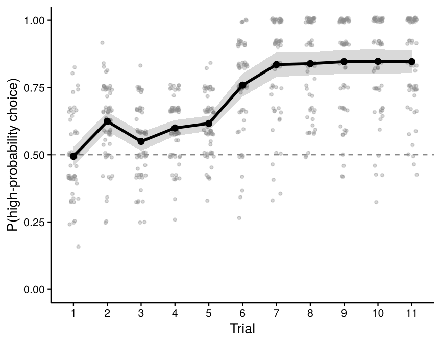

```r
fig_overall_curve <- ggplot(overall_curve_participant, aes(x = trial, y = accuracy)) +
  geom_hline(yintercept = chance_level, linetype = "dashed", colour = "grey50", linewidth = 0.4) +
  geom_point(position = position_jitter(width = 0.15, height = 0.01, seed = 1),
             colour = "grey55", alpha = 0.35, size = 0.8) +
  geom_ribbon(data = overall_curve_summary, aes(x = trial, ymin = ci_low, ymax = ci_high),
              inherit.aes = FALSE, fill = "black", alpha = 0.15) +
  geom_line(data = overall_curve_summary, aes(x = trial, y = mean), inherit.aes = FALSE, linewidth = 1) +
  geom_point(data = overall_curve_summary, aes(x = trial, y = mean), inherit.aes = FALSE, size = 1.8) +
  scale_x_continuous(breaks = sort(unique(overall_curve_participant$trial))) +
  coord_cartesian(ylim = c(0, 1)) +
  labs(x = "Trial", y = "P(high-probability choice)")

fig_overall_curve
```

```r
ggsave(file.path(output_dir, "fig2_overall_learning_curve.png"), fig_overall_curve,
       width = 110, height = 85, units = "mm", dpi = 300)
```

# 7. Learning curve by grouping

```r
grouping_curve_participant <- trial_data %>%
  group_by(participant, grouping, trial_num) %>%
  summarise(accuracy = mean(choice_correct, na.rm = TRUE), .groups = "drop") %>%
  filter(!is.na(accuracy)) %>%
  mutate(trial = trial_num + 1)

grouping_accuracy_wide <- trial_data %>%
  group_by(participant, grouping) %>%
  summarise(accuracy = mean(choice_correct, na.rm = TRUE), .groups = "drop") %>%
  pivot_wider(names_from = grouping, values_from = accuracy) %>%
  filter(!is.na(`in`), !is.na(out))
```

```r
# model terms
coef(summary(choice_model))["grouping1", ]
```

```
##    Estimate  Std. Error     z value    Pr(>|z|)
## 0.076871760 0.027290509 2.816794623 0.004850553
```

```r
# planned contrast: accuracy at the mean trial, in - out (log-odds), averaged over IQ
grouping_accuracy_emm <- emmeans(choice_model, ~ grouping)
```

```
## NOTE: Results may be misleading due to involvement in interactions
```

```r
summary(pairs(grouping_accuracy_emm), infer = c(TRUE, TRUE))
```

```
##  contrast estimate     SE  df asymp.LCL asymp.UCL z.ratio p.value
##  in - out    0.154 0.0546 Inf    0.0468     0.261   2.817  0.0048
##
## Results are averaged over the levels of: iq
## Results are given on the log odds ratio (not the response) scale.
## Confidence level used: 0.95
```

```r
summary(grouping_accuracy_emm, type = "response")     # estimated P(high-probability choice) per group
```

```
##  grouping  prob     SE  df asymp.LCL asymp.UCL
##  in       0.756 0.0133 Inf     0.729     0.781
##  out      0.726 0.0141 Inf     0.698     0.753
##
## Results are averaged over the levels of: iq
## Confidence level used: 0.95
## Intervals are back-transformed from the logit scale
```

**Descriptive statistics and effect size** (participant-level mean accuracy over all trials). In-group vs. out-group is compared with a Wilcoxon signed-rank test on each participant’s two mean accuracies.

```r
grouping_accuracy_wilcox_test <- wilcox.test(grouping_accuracy_wide$`in`, grouping_accuracy_wide$out, paired = TRUE)
grouping_accuracy_wilcox_test
```

```
##
##  Wilcoxon signed rank test with continuity correction
##
## data:  grouping_accuracy_wide$`in` and grouping_accuracy_wide$out
## V = 1186, p-value = 0.00433
## alternative hypothesis: true location shift is not equal to 0
```

```r
# effect size: matched-pairs rank-biserial correlation (zero differences dropped, as in wilcox.test)
grouping_accuracy_difference <- grouping_accuracy_wide$`in` - grouping_accuracy_wide$out
grouping_nonzero_difference  <- grouping_accuracy_difference[grouping_accuracy_difference != 0]
grouping_difference_ranks    <- rank(abs(grouping_nonzero_difference))

tibble(n             = nrow(grouping_accuracy_wide),
       mean_in       = mean(grouping_accuracy_wide$`in`),
       sem_in        = sd(grouping_accuracy_wide$`in`) / sqrt(nrow(grouping_accuracy_wide)),
       mean_out      = mean(grouping_accuracy_wide$out),
       sem_out       = sd(grouping_accuracy_wide$out) / sqrt(nrow(grouping_accuracy_wide)),
       mean_diff     = mean(grouping_accuracy_difference),
       median_diff   = median(grouping_accuracy_difference),
       V             = unname(grouping_accuracy_wilcox_test$statistic),
       p_wilcox      = grouping_accuracy_wilcox_test$p.value,
       rank_biserial = (sum(grouping_difference_ranks[grouping_nonzero_difference > 0]) -
                        sum(grouping_difference_ranks[grouping_nonzero_difference < 0])) / sum(grouping_difference_ranks)) %>%
  mutate(p_wilcox = scales::pvalue(p_wilcox, accuracy = 0.001), across(where(is.numeric), ~ round(.x, 3)))
```

```
## # A tibble: 1 x 10
##       n mean_in sem_in mean_out sem_out mean_diff median_diff     V p_wilcox
##   <dbl>   <dbl>  <dbl>    <dbl>   <dbl>     <dbl>       <dbl> <dbl> <chr>
## 1    62   0.726  0.014    0.702   0.015     0.024       0.017  1186 0.004
## # i 1 more variable: rank_biserial <dbl>
```

```r
grouping_curve_summary <- grouping_curve_participant %>%
  group_by(grouping, trial) %>%
  summarise(n = n(), mean = mean(accuracy), sd = sd(accuracy), .groups = "drop") %>%
  mutate(ci_low  = mean - qt(0.975, n - 1) * sd / sqrt(n),
         ci_high = mean + qt(0.975, n - 1) * sd / sqrt(n))

grouping_curve_summary %>% mutate(across(where(is.numeric), ~ round(.x, 3)))
```

```
## # A tibble: 22 x 7
##    grouping trial     n  mean    sd ci_low ci_high
##    <fct>    <dbl> <dbl> <dbl> <dbl>  <dbl>   <dbl>
##  1 in           1    62 0.501 0.185  0.454   0.548
##  2 in           2    62 0.647 0.208  0.595   0.7
##  3 in           3    62 0.539 0.152  0.501   0.578
##  4 in           4    62 0.625 0.172  0.581   0.669
##  5 in           5    62 0.612 0.194  0.562   0.661
##  6 in           6    62 0.763 0.226  0.706   0.821
##  7 in           7    62 0.846 0.207  0.794   0.899
##  8 in           8    62 0.865 0.182  0.818   0.911
##  9 in           9    62 0.862 0.196  0.812   0.912
## 10 in          10    62 0.843 0.231  0.784   0.902
## # i 12 more rows
```

**Figure.**

- 1. Learning curves. Small points are participant-level accuracies per trial, shifted slightly left (in-group) or right (out-group). Lines and ribbons show the mean and 95% CI.
- 2. Participant-mean accuracy over all trials. Bars show the mean ± SEM, white points are participants, and grey lines connect the same participant’s in-group and out-group values. Asterisks appear only if the Wilcoxon signed-rank test is significant.

```r
grouping_curve_plot_data <- grouping_curve_participant %>%
  mutate(x_point = trial + ifelse(grouping == "in", -0.15, 0.15))

fig_grouping_curve <- ggplot(grouping_curve_plot_data, aes(x = x_point, y = accuracy, colour = grouping)) +
  geom_hline(yintercept = chance_level, linetype = "dashed", colour = "grey50", linewidth = 0.4) +
  geom_point(position = position_jitter(width = 0.06, height = 0.01, seed = 1), alpha = 0.25, size = 0.7) +
  geom_ribbon(data = grouping_curve_summary, aes(x = trial, ymin = ci_low, ymax = ci_high, fill = grouping),
              inherit.aes = FALSE, alpha = 0.15) +
  geom_line(data = grouping_curve_summary, aes(x = trial, y = mean, colour = grouping), inherit.aes = FALSE, linewidth = 1) +
  geom_point(data = grouping_curve_summary, aes(x = trial, y = mean, colour = grouping), inherit.aes = FALSE, size = 1.8) +
  scale_colour_manual(values = colour_grouping, labels = label_grouping, name = NULL) +
  scale_fill_manual(values = colour_grouping, labels = label_grouping, name = NULL) +
  scale_x_continuous(breaks = sort(unique(grouping_curve_participant$trial))) +
  coord_cartesian(ylim = c(0, 1)) +
  labs(x = "Trial", y = "P(high-probability choice)")

set.seed(1)
grouping_accuracy_jitter <- tibble(participant = grouping_accuracy_wide$participant,
                                 jitter      = runif(nrow(grouping_accuracy_wide), -0.12, 0.12))

grouping_accuracy_plot_data <- grouping_accuracy_wide %>%
  pivot_longer(c(`in`, out), names_to = "grouping", values_to = "accuracy") %>%
  left_join(grouping_accuracy_jitter, by = "participant") %>%
  mutate(grouping = factor(grouping, levels = c("in", "out")),
         x_point  = as.numeric(grouping) + jitter)

grouping_accuracy_plot_summary <- grouping_accuracy_plot_data %>%
  group_by(grouping) %>%
  summarise(n = n(), mean = mean(accuracy), sem = sd(accuracy) / sqrt(n()), .groups = "drop") %>%
  mutate(x_bar = as.numeric(grouping))

grouping_accuracy_significance <- tibble(p = grouping_accuracy_wilcox_test$p.value,
                                  y = max(grouping_accuracy_plot_data$accuracy) + 0.04) %>%
  filter(p < .05) %>%
  mutate(label = case_when(p < .001 ~ "***", p < .01 ~ "**", TRUE ~ "*"))

fig_grouping_accuracy <- ggplot(grouping_accuracy_plot_data, aes(x = x_point, y = accuracy)) +
  geom_col(data = grouping_accuracy_plot_summary, aes(x = x_bar, y = mean, fill = grouping),
           inherit.aes = FALSE, width = 0.6, alpha = 0.55, colour = NA) +
  geom_hline(yintercept = chance_level, linetype = "dashed", colour = "grey50", linewidth = 0.4) +
  geom_line(aes(group = participant), colour = "grey70", linewidth = 0.25, alpha = 0.7) +
  geom_point(shape = 21, fill = "white", colour = "grey25", size = 1.3, stroke = 0.4) +
  geom_errorbar(data = grouping_accuracy_plot_summary, aes(x = x_bar, ymin = mean - sem, ymax = mean + sem),
                inherit.aes = FALSE, width = 0.12, linewidth = 0.7) +
  geom_segment(data = grouping_accuracy_significance, aes(x = 1, xend = 2, y = y, yend = y), inherit.aes = FALSE, linewidth = 0.6) +
  geom_text(data = grouping_accuracy_significance, aes(x = 1.5, y = y, label = label), inherit.aes = FALSE, vjust = -0.2, size = 5) +
  scale_x_continuous(breaks = 1:2, labels = label_grouping[c("in", "out")], expand = expansion(add = 0.5)) +
  scale_fill_manual(values = colour_grouping, guide = "none") +
  scale_y_continuous(breaks = seq(0.5, 0.9, 0.1)) +
  coord_cartesian(xlim = c(0.4, 2.6), ylim = c(0.5, 1.08), expand = FALSE) +
  labs(x = "Demonstrator group", y = "Mean P(high-probability choice)")

# participant values below the visible range (0.5) are not shown in panel B
sum(grouping_accuracy_plot_data$accuracy < 0.5)
```

```
## [1] 4
```

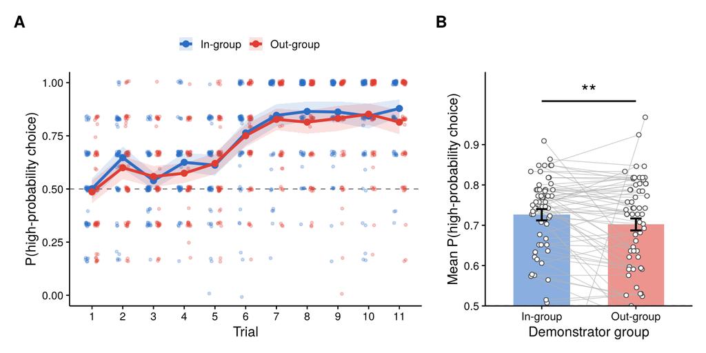

```r
fig_learning_by_grouping <- (fig_grouping_curve | fig_grouping_accuracy) +
  plot_layout(widths = c(1.7, 1)) + plot_annotation(tag_levels = "A")
fig_learning_by_grouping
```

```r
ggsave(file.path(output_dir, "fig3_learning_curve_by_grouping.png"), fig_learning_by_grouping,
       width = 183, height = 90, units = "mm", dpi = 300)
```

# 8. Learning curve by IQ

```r
iq_curve_participant <- trial_data %>%
  group_by(participant, iq, trial_num) %>%
  summarise(accuracy = mean(choice_correct, na.rm = TRUE), .groups = "drop") %>%
  filter(!is.na(accuracy)) %>%
  mutate(trial = trial_num + 1)

iq_accuracy_wide <- trial_data %>%
  group_by(participant, iq) %>%
  summarise(accuracy = mean(choice_correct, na.rm = TRUE), .groups = "drop") %>%
  pivot_wider(names_from = iq, values_from = accuracy) %>%
  filter(!is.na(high), !is.na(low))
```

**Statistical tests.** These use the choice learning model (section 5): term `iq1`, equivalently the planned contrast high − low for accuracy at the mean trial (averaged over grouping). Differences in learning rate are not tested here.

```r
coef(summary(choice_model))["iq1", ]
```

```
##    Estimate  Std. Error     z value    Pr(>|z|)
## 0.078494214 0.027312301 2.873950984 0.004053719
```

```r
iq_accuracy_emm <- emmeans(choice_model, ~ iq)
```

```
## NOTE: Results may be misleading due to involvement in interactions
```

```r
summary(pairs(iq_accuracy_emm), infer = c(TRUE, TRUE))
```

```
##  contrast   estimate     SE  df asymp.LCL asymp.UCL z.ratio p.value
##  high - low    0.157 0.0546 Inf      0.05     0.264   2.875  0.0040
##
## Results are averaged over the levels of: grouping
## Results are given on the log odds ratio (not the response) scale.
## Confidence level used: 0.95
```

```r
summary(iq_accuracy_emm, type = "response")
```

```
##  iq    prob     SE  df asymp.LCL asymp.UCL
##  high 0.756 0.0133 Inf     0.729     0.781
##  low  0.726 0.0142 Inf     0.697     0.753
##
## Results are averaged over the levels of: grouping
## Confidence level used: 0.95
## Intervals are back-transformed from the logit scale
```

**Descriptive statistics and effect size.** High vs. low IQ is compared in the same way as in section 7 (Wilcoxon signed-rank test, rank-biserial correlation; positive = higher accuracy for high IQ).

```r
iq_accuracy_wilcox_test <- wilcox.test(iq_accuracy_wide$high, iq_accuracy_wide$low, paired = TRUE)
iq_accuracy_wilcox_test
```

```
##
##  Wilcoxon signed rank test with continuity correction
##
## data:  iq_accuracy_wide$high and iq_accuracy_wide$low
## V = 1155.5, p-value = 0.07716
## alternative hypothesis: true location shift is not equal to 0
```

```r
# effect size: matched-pairs rank-biserial correlation (zero differences dropped, as in wilcox.test)
iq_accuracy_difference <- iq_accuracy_wide$high - iq_accuracy_wide$low
iq_nonzero_difference  <- iq_accuracy_difference[iq_accuracy_difference != 0]
iq_difference_ranks    <- rank(abs(iq_nonzero_difference))

tibble(n             = nrow(iq_accuracy_wide),
       mean_high       = mean(iq_accuracy_wide$high),
       sem_high        = sd(iq_accuracy_wide$high) / sqrt(nrow(iq_accuracy_wide)),
       mean_low      = mean(iq_accuracy_wide$low),
       sem_low       = sd(iq_accuracy_wide$low) / sqrt(nrow(iq_accuracy_wide)),
       mean_diff     = mean(iq_accuracy_difference),
       median_diff   = median(iq_accuracy_difference),
       V             = unname(iq_accuracy_wilcox_test$statistic),
       p_wilcox      = iq_accuracy_wilcox_test$p.value,
       rank_biserial = (sum(iq_difference_ranks[iq_nonzero_difference > 0]) -
                        sum(iq_difference_ranks[iq_nonzero_difference < 0])) / sum(iq_difference_ranks)) %>%
  mutate(p_wilcox = scales::pvalue(p_wilcox, accuracy = 0.001), across(where(is.numeric), ~ round(.x, 3)))
```

```
## # A tibble: 1 x 10
##       n mean_high sem_high mean_low sem_low mean_diff median_diff     V p_wilcox
##   <dbl>     <dbl>    <dbl>    <dbl>   <dbl>     <dbl>       <dbl> <dbl> <chr>
## 1    62     0.726    0.013    0.702   0.014     0.024       0.015 1156. 0.077
## # i 1 more variable: rank_biserial <dbl>
```

```r
iq_curve_summary <- iq_curve_participant %>%
  group_by(iq, trial) %>%
  summarise(n = n(), mean = mean(accuracy), sd = sd(accuracy), .groups = "drop") %>%
  mutate(ci_low  = mean - qt(0.975, n - 1) * sd / sqrt(n),
         ci_high = mean + qt(0.975, n - 1) * sd / sqrt(n))

iq_curve_summary %>% mutate(across(where(is.numeric), ~ round(.x, 3)))
```

```
## # A tibble: 22 x 7
##    iq    trial     n  mean    sd ci_low ci_high
##    <fct> <dbl> <dbl> <dbl> <dbl>  <dbl>   <dbl>
##  1 high      1    62 0.499 0.203  0.447   0.551
##  2 high      2    62 0.655 0.193  0.606   0.704
##  3 high      3    62 0.528 0.174  0.484   0.573
##  4 high      4    62 0.602 0.174  0.557   0.646
##  5 high      5    62 0.611 0.159  0.571   0.652
##  6 high      6    62 0.787 0.184  0.74    0.834
##  7 high      7    62 0.864 0.192  0.815   0.913
##  8 high      8    62 0.864 0.179  0.818   0.91
##  9 high      9    62 0.856 0.203  0.804   0.908
## 10 high     10    62 0.863 0.206  0.811   0.916
## # i 12 more rows
```

**Figure.** The layout is the same as in section 7.

```r
iq_curve_plot_data <- iq_curve_participant %>%
  mutate(x_point = trial + ifelse(iq == "high", -0.15, 0.15))

fig_iq_curve <- ggplot(iq_curve_plot_data, aes(x = x_point, y = accuracy, colour = iq)) +
  geom_hline(yintercept = chance_level, linetype = "dashed", colour = "grey50", linewidth = 0.4) +
  geom_point(position = position_jitter(width = 0.06, height = 0.01, seed = 1), alpha = 0.25, size = 0.7) +
  geom_ribbon(data = iq_curve_summary, aes(x = trial, ymin = ci_low, ymax = ci_high, fill = iq),
              inherit.aes = FALSE, alpha = 0.15) +
  geom_line(data = iq_curve_summary, aes(x = trial, y = mean, colour = iq), inherit.aes = FALSE, linewidth = 1) +
  geom_point(data = iq_curve_summary, aes(x = trial, y = mean, colour = iq), inherit.aes = FALSE, size = 1.8) +
  scale_colour_manual(values = colour_iq, labels = label_iq, name = NULL) +
  scale_fill_manual(values = colour_iq, labels = label_iq, name = NULL) +
  scale_x_continuous(breaks = sort(unique(iq_curve_participant$trial))) +
  coord_cartesian(ylim = c(0, 1)) +
  labs(x = "Trial", y = "P(high-probability choice)")

set.seed(1)
iq_accuracy_jitter <- tibble(participant = iq_accuracy_wide$participant,
                                 jitter      = runif(nrow(iq_accuracy_wide), -0.12, 0.12))

iq_accuracy_plot_data <- iq_accuracy_wide %>%
  pivot_longer(c(high, low), names_to = "iq", values_to = "accuracy") %>%
  left_join(iq_accuracy_jitter, by = "participant") %>%
  mutate(iq = factor(iq, levels = c("high", "low")),
         x_point  = as.numeric(iq) + jitter)

iq_accuracy_plot_summary <- iq_accuracy_plot_data %>%
  group_by(iq) %>%
  summarise(n = n(), mean = mean(accuracy), sem = sd(accuracy) / sqrt(n()), .groups = "drop") %>%
  mutate(x_bar = as.numeric(iq))

iq_accuracy_significance <- tibble(p = iq_accuracy_wilcox_test$p.value,
                                  y = max(iq_accuracy_plot_data$accuracy) + 0.04) %>%
  filter(p < .05) %>%
  mutate(label = case_when(p < .001 ~ "***", p < .01 ~ "**", TRUE ~ "*"))

fig_iq_accuracy <- ggplot(iq_accuracy_plot_data, aes(x = x_point, y = accuracy)) +
  geom_col(data = iq_accuracy_plot_summary, aes(x = x_bar, y = mean, fill = iq),
           inherit.aes = FALSE, width = 0.6, alpha = 0.55, colour = NA) +
  geom_hline(yintercept = chance_level, linetype = "dashed", colour = "grey50", linewidth = 0.4) +
  geom_line(aes(group = participant), colour = "grey70", linewidth = 0.25, alpha = 0.7) +
  geom_point(shape = 21, fill = "white", colour = "grey25", size = 1.3, stroke = 0.4) +
  geom_errorbar(data = iq_accuracy_plot_summary, aes(x = x_bar, ymin = mean - sem, ymax = mean + sem),
                inherit.aes = FALSE, width = 0.12, linewidth = 0.7) +
  geom_segment(data = iq_accuracy_significance, aes(x = 1, xend = 2, y = y, yend = y), inherit.aes = FALSE, linewidth = 0.6) +
  geom_text(data = iq_accuracy_significance, aes(x = 1.5, y = y, label = label), inherit.aes = FALSE, vjust = -0.2, size = 5) +
  scale_x_continuous(breaks = 1:2, labels = label_iq[c("high", "low")], expand = expansion(add = 0.5)) +
  scale_fill_manual(values = colour_iq, guide = "none") +
  scale_y_continuous(breaks = seq(0.5, 0.9, 0.1)) +
  coord_cartesian(xlim = c(0.4, 2.6), ylim = c(0.5, 1.08), expand = FALSE) +
  labs(x = "Demonstrator IQ", y = "Mean P(high-probability choice)")

# participant values below the visible range (0.5) are not shown in panel B
sum(iq_accuracy_plot_data$accuracy < 0.5)
```

```
## [1] 4
```

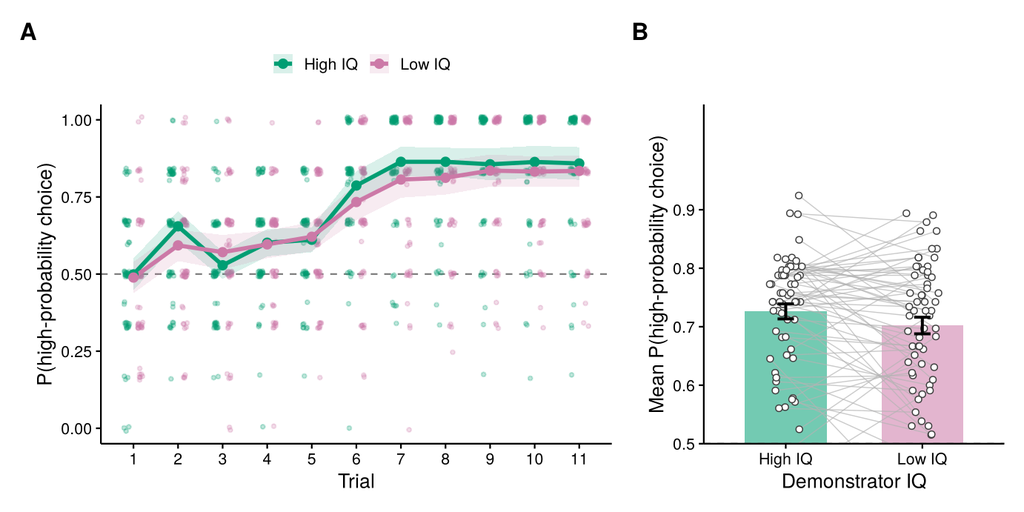

```r
fig_learning_by_iq <- (fig_iq_curve | fig_iq_accuracy) +
  plot_layout(widths = c(1.7, 1)) + plot_annotation(tag_levels = "A")
fig_learning_by_iq
```

```r
ggsave(file.path(output_dir, "fig4_learning_curve_by_iq.png"), fig_learning_by_iq,
       width = 183, height = 90, units = "mm", dpi = 300)
```

# 9. Learning curves of the four conditions and interaction plot (figures only)

```r
condition_levels <- c("In-group, High IQ", "In-group, Low IQ", "Out-group, High IQ", "Out-group, Low IQ")
```

## 9.1 Learning curves of the four conditions in one plot

```r
condition_curve_participant <- trial_data %>%
  group_by(participant, grouping, iq, trial_num) %>%
  summarise(accuracy = mean(choice_correct, na.rm = TRUE), .groups = "drop") %>%
  filter(!is.na(accuracy)) %>%
  mutate(trial     = trial_num + 1,
         condition = factor(paste0(label_grouping[as.character(grouping)], ", ", label_iq[as.character(iq)]),
                            levels = condition_levels))

condition_curve_summary <- condition_curve_participant %>%
  group_by(condition, grouping, iq, trial) %>%
  summarise(n = n(), mean = mean(accuracy), sd = sd(accuracy), .groups = "drop") %>%
  mutate(ci_low  = mean - qt(0.975, n - 1) * sd / sqrt(n),
         ci_high = mean + qt(0.975, n - 1) * sd / sqrt(n))

condition_curve_summary %>% mutate(across(where(is.numeric), ~ round(.x, 3)))
```

```
## # A tibble: 44 x 9
##    condition         grouping iq    trial     n  mean    sd ci_low ci_high
##    <fct>             <fct>    <fct> <dbl> <dbl> <dbl> <dbl>  <dbl>   <dbl>
##  1 In-group, High IQ in       high      1    62 0.497 0.267  0.429   0.565
##  2 In-group, High IQ in       high      2    62 0.702 0.265  0.634   0.769
##  3 In-group, High IQ in       high      3    62 0.546 0.242  0.484   0.607
##  4 In-group, High IQ in       high      4    62 0.629 0.257  0.564   0.694
##  5 In-group, High IQ in       high      5    62 0.648 0.267  0.58    0.716
##  6 In-group, High IQ in       high      6    62 0.796 0.257  0.73    0.861
##  7 In-group, High IQ in       high      7    62 0.868 0.24   0.807   0.929
##  8 In-group, High IQ in       high      8    62 0.892 0.207  0.84    0.945
##  9 In-group, High IQ in       high      9    62 0.874 0.231  0.815   0.932
## 10 In-group, High IQ in       high     10    62 0.839 0.312  0.759   0.918
## # i 34 more rows
```

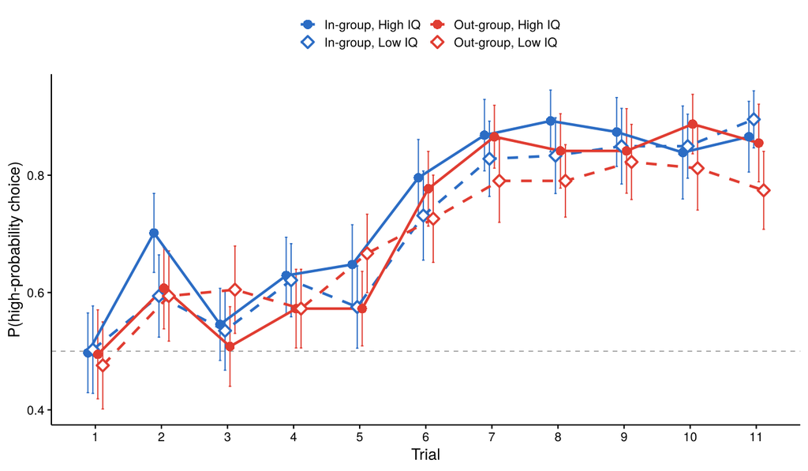

```r
fig_condition_curves_combined <- ggplot(condition_curve_summary,
                                        aes(x = trial, y = mean, colour = condition, linetype = condition, shape = condition)) +
  geom_hline(yintercept = chance_level, linetype = "dashed", colour = "grey60", linewidth = 0.3) +
  geom_errorbar(aes(ymin = ci_low, ymax = ci_high), width = 0.15, linewidth = 0.35, linetype = "solid",
                position = position_dodge(width = 0.3), show.legend = FALSE) +
  geom_line(linewidth = 0.8, position = position_dodge(width = 0.3)) +
  geom_point(size = 2.2, stroke = 1, fill = "white", position = position_dodge(width = 0.3)) +
  scale_colour_manual(values = setNames(unname(colour_grouping[c("in", "in", "out", "out")]), condition_levels), name = NULL) +
  scale_linetype_manual(values = setNames(c("solid", "dashed", "solid", "dashed"), condition_levels), name = NULL) +
  scale_shape_manual(values = setNames(c(16, 23, 16, 23), condition_levels), name = NULL) +
  scale_x_continuous(breaks = sort(unique(condition_curve_summary$trial))) +
  labs(x = "Trial", y = "P(high-probability choice)") +
  guides(colour = guide_legend(nrow = 2), linetype = guide_legend(nrow = 2), shape = guide_legend(nrow = 2))

fig_condition_curves_combined
```

```r
ggsave(file.path(output_dir, "fig5_learning_curves_four_conditions.png"), fig_condition_curves_combined,
       width = 183, height = 105, units = "mm", dpi = 300)
```

## 9.2 Interaction plot: group x IQ (overall choice accuracy)

Each participant’s mean choice accuracy over all trials of each condition is computed first. The plot shows the mean of these participant values per condition with ± 1 SEM error bars, as in the original interaction plot. Lines connect the two groups within each IQ level. The y-axis is zoomed in on the condition means, so it does not start at 0.

```r
interaction_cells <- trial_data %>%
  group_by(participant, grouping, iq) %>%
  summarise(accuracy = mean(choice_correct, na.rm = TRUE), .groups = "drop") %>%
  filter(!is.na(accuracy))

interaction_summary <- interaction_cells %>%
  group_by(grouping, iq) %>%
  summarise(n = n(), mean = mean(accuracy), sd = sd(accuracy), .groups = "drop") %>%
  mutate(sem = sd / sqrt(n))

interaction_summary %>% mutate(across(where(is.numeric), ~ round(.x, 3)))
```

```
## # A tibble: 4 x 6
##   grouping iq        n  mean    sd   sem
##   <fct>    <fct> <dbl> <dbl> <dbl> <dbl>
## 1 in       high     62 0.741 0.135 0.017
## 2 in       low      62 0.711 0.126 0.016
## 3 out      high     62 0.711 0.128 0.016
## 4 out      low      62 0.693 0.137 0.017
```

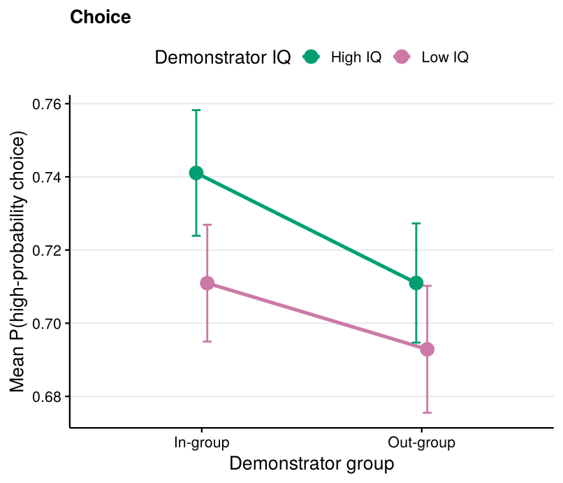

```r
fig_interaction <- ggplot(interaction_summary, aes(x = grouping, y = mean, colour = iq, group = iq)) +
  geom_line(linewidth = 0.9, position = position_dodge(width = 0.1)) +
  geom_errorbar(aes(ymin = mean - sem, ymax = mean + sem), width = 0.08, linewidth = 0.5,
                position = position_dodge(width = 0.1)) +
  geom_point(size = 3, position = position_dodge(width = 0.1)) +
  scale_x_discrete(labels = label_grouping) +
  scale_colour_manual(values = colour_iq, labels = label_iq, name = "Demonstrator IQ") +
  labs(x = "Demonstrator group", y = "Mean P(high-probability choice)", title = "Choice") +
  theme(panel.grid.major.y = element_line(colour = "grey90", linewidth = 0.3))

fig_interaction
```

```r
ggsave(file.path(output_dir, "fig6_interaction_group_by_iq.png"), fig_interaction,
       width = 105, height = 90, units = "mm", dpi = 300)
```

# 10. Prediction

`pred_correct` = 1 if the participant’s prediction matched the demonstrator’s actual choice. These figures are descriptive.

## 10.1 Prediction learning curves by group and by IQ

Each participant’s prediction accuracy on each trial is averaged over the blocks of each level (in-group / out-group, or high / low IQ). Lines and ribbons show the mean and 95% CI across participants. The dashed line is chance. Both panels are saved as one image.

```r
prediction_grouping_curve_summary <- trial_data %>%
  group_by(participant, grouping, trial_num) %>%
  summarise(accuracy = mean(pred_correct, na.rm = TRUE), .groups = "drop") %>%
  filter(!is.na(accuracy)) %>%
  mutate(trial = trial_num + 1) %>%
  group_by(grouping, trial) %>%
  summarise(n = n(), mean = mean(accuracy), sd = sd(accuracy), .groups = "drop") %>%
  mutate(ci_low  = mean - qt(0.975, n - 1) * sd / sqrt(n),
         ci_high = mean + qt(0.975, n - 1) * sd / sqrt(n))

prediction_iq_curve_summary <- trial_data %>%
  group_by(participant, iq, trial_num) %>%
  summarise(accuracy = mean(pred_correct, na.rm = TRUE), .groups = "drop") %>%
  filter(!is.na(accuracy)) %>%
  mutate(trial = trial_num + 1) %>%
  group_by(iq, trial) %>%
  summarise(n = n(), mean = mean(accuracy), sd = sd(accuracy), .groups = "drop") %>%
  mutate(ci_low  = mean - qt(0.975, n - 1) * sd / sqrt(n),
         ci_high = mean + qt(0.975, n - 1) * sd / sqrt(n))

prediction_grouping_curve_summary %>% mutate(across(where(is.numeric), ~ round(.x, 3)))
```

```
## # A tibble: 22 x 7
##    grouping trial     n  mean    sd ci_low ci_high
##    <fct>    <dbl> <dbl> <dbl> <dbl>  <dbl>   <dbl>
##  1 in           1    62 0.555 0.207  0.502   0.607
##  2 in           2    62 0.483 0.211  0.43    0.537
##  3 in           3    62 0.527 0.187  0.48    0.575
##  4 in           4    62 0.482 0.178  0.437   0.528
##  5 in           5    62 0.485 0.197  0.435   0.535
##  6 in           6    62 0.644 0.182  0.598   0.69
##  7 in           7    62 0.738 0.206  0.686   0.79
##  8 in           8    62 0.813 0.218  0.758   0.869
##  9 in           9    62 0.852 0.196  0.802   0.901
## 10 in          10    62 0.83  0.229  0.772   0.888
## # i 12 more rows
```

```r
prediction_iq_curve_summary %>% mutate(across(where(is.numeric), ~ round(.x, 3)))
```

```
## # A tibble: 22 x 7
##    iq    trial     n  mean    sd ci_low ci_high
##    <fct> <dbl> <dbl> <dbl> <dbl>  <dbl>   <dbl>
##  1 high      1    62 0.539 0.211  0.486   0.593
##  2 high      2    62 0.49  0.239  0.43    0.551
##  3 high      3    62 0.492 0.196  0.443   0.542
##  4 high      4    62 0.506 0.17   0.463   0.55
##  5 high      5    62 0.468 0.163  0.427   0.51
##  6 high      6    62 0.631 0.154  0.592   0.67
##  7 high      7    62 0.78  0.193  0.731   0.829
##  8 high      8    62 0.842 0.193  0.793   0.892
##  9 high      9    62 0.855 0.204  0.803   0.907
## 10 high     10    62 0.831 0.242  0.769   0.892
## # i 12 more rows
```

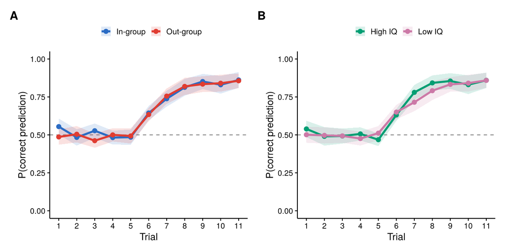

```r
fig_prediction_curve_grouping <- ggplot(prediction_grouping_curve_summary, aes(x = trial, y = mean, colour = grouping)) +
  geom_hline(yintercept = chance_level, linetype = "dashed", colour = "grey50", linewidth = 0.4) +
  geom_ribbon(aes(ymin = ci_low, ymax = ci_high, fill = grouping), colour = NA, alpha = 0.15) +
  geom_line(linewidth = 1) +
  geom_point(size = 1.8) +
  scale_colour_manual(values = colour_grouping, labels = label_grouping, name = NULL) +
  scale_fill_manual(values = colour_grouping, labels = label_grouping, name = NULL) +
  scale_x_continuous(breaks = sort(unique(prediction_grouping_curve_summary$trial))) +
  coord_cartesian(ylim = c(0, 1)) +
  labs(x = "Trial", y = "P(correct prediction)")

fig_prediction_curve_iq <- ggplot(prediction_iq_curve_summary, aes(x = trial, y = mean, colour = iq)) +
  geom_hline(yintercept = chance_level, linetype = "dashed", colour = "grey50", linewidth = 0.4) +
  geom_ribbon(aes(ymin = ci_low, ymax = ci_high, fill = iq), colour = NA, alpha = 0.15) +
  geom_line(linewidth = 1) +
  geom_point(size = 1.8) +
  scale_colour_manual(values = colour_iq, labels = label_iq, name = NULL) +
  scale_fill_manual(values = colour_iq, labels = label_iq, name = NULL) +
  scale_x_continuous(breaks = sort(unique(prediction_iq_curve_summary$trial))) +
  coord_cartesian(ylim = c(0, 1)) +
  labs(x = "Trial", y = "P(correct prediction)")

fig_prediction_marginal <- (fig_prediction_curve_grouping | fig_prediction_curve_iq) + plot_annotation(tag_levels = "A")
fig_prediction_marginal
```

```r
ggsave(file.path(output_dir, "prediction_marginal.png"), fig_prediction_marginal,
       width = 183, height = 85, units = "mm", dpi = 300)
```

## 10.2 Prediction learning curves of the four conditions in one plot

Same layout as the choice curves in 9.1: mean ± 95% CI per trial. Colour shows group, and line type and marker show IQ: solid line and filled circle = high IQ, dashed line and open diamond = low IQ.

```r
condition_prediction_curve_summary <- trial_data %>%
  group_by(participant, grouping, iq, trial_num) %>%
  summarise(accuracy = mean(pred_correct, na.rm = TRUE), .groups = "drop") %>%
  filter(!is.na(accuracy)) %>%
  mutate(trial     = trial_num + 1,
         condition = factor(paste0(label_grouping[as.character(grouping)], ", ", label_iq[as.character(iq)]),
                            levels = condition_levels)) %>%
  group_by(condition, grouping, iq, trial) %>%
  summarise(n = n(), mean = mean(accuracy), sd = sd(accuracy), .groups = "drop") %>%
  mutate(ci_low  = mean - qt(0.975, n - 1) * sd / sqrt(n),
         ci_high = mean + qt(0.975, n - 1) * sd / sqrt(n))

condition_prediction_curve_summary %>% mutate(across(where(is.numeric), ~ round(.x, 3)))
```

```
## # A tibble: 44 x 9
##    condition         grouping iq    trial     n  mean    sd ci_low ci_high
##    <fct>             <fct>    <fct> <dbl> <dbl> <dbl> <dbl>  <dbl>   <dbl>
##  1 In-group, High IQ in       high      1    62 0.562 0.251  0.498   0.626
##  2 In-group, High IQ in       high      2    62 0.495 0.294  0.42    0.569
##  3 In-group, High IQ in       high      3    62 0.497 0.26   0.431   0.563
##  4 In-group, High IQ in       high      4    62 0.5   0.232  0.441   0.559
##  5 In-group, High IQ in       high      5    62 0.468 0.252  0.404   0.532
##  6 In-group, High IQ in       high      6    62 0.64  0.258  0.574   0.705
##  7 In-group, High IQ in       high      7    62 0.772 0.249  0.708   0.835
##  8 In-group, High IQ in       high      8    62 0.815 0.263  0.748   0.881
##  9 In-group, High IQ in       high      9    62 0.866 0.221  0.809   0.922
## 10 In-group, High IQ in       high     10    62 0.828 0.261  0.762   0.894
## # i 34 more rows
```

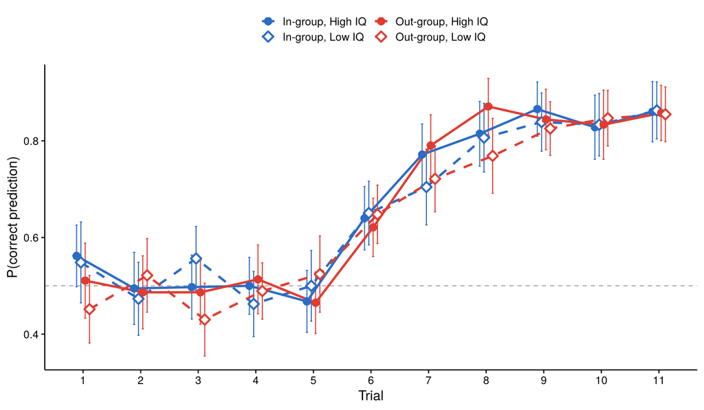

```r
fig_combined_prediction_curve <- ggplot(condition_prediction_curve_summary,
                                        aes(x = trial, y = mean, colour = condition, linetype = condition, shape = condition)) +
  geom_hline(yintercept = chance_level, linetype = "dashed", colour = "grey60", linewidth = 0.3) +
  geom_errorbar(aes(ymin = ci_low, ymax = ci_high), width = 0.15, linewidth = 0.35, linetype = "solid",
                position = position_dodge(width = 0.3), show.legend = FALSE) +
  geom_line(linewidth = 0.8, position = position_dodge(width = 0.3)) +
  geom_point(size = 2.2, stroke = 1, fill = "white", position = position_dodge(width = 0.3)) +
  scale_colour_manual(values = setNames(unname(colour_grouping[c("in", "in", "out", "out")]), condition_levels), name = NULL) +
  scale_linetype_manual(values = setNames(c("solid", "dashed", "solid", "dashed"), condition_levels), name = NULL) +
  scale_shape_manual(values = setNames(c(16, 23, 16, 23), condition_levels), name = NULL) +
  scale_x_continuous(breaks = sort(unique(condition_prediction_curve_summary$trial))) +
  labs(x = "Trial", y = "P(correct prediction)") +
  guides(colour = guide_legend(nrow = 2), linetype = guide_legend(nrow = 2), shape = guide_legend(nrow = 2))

fig_combined_prediction_curve
```

```r
ggsave(file.path(output_dir, "combined_prediction_curve.png"), fig_combined_prediction_curve,
       width = 183, height = 105, units = "mm", dpi = 300)
```

# 11. Imitation

`imitated` = 1 if the participant’s choice matched the demonstrator’s choice (high- vs. low-probability image).

## 11.1 Interaction plot: imitation in the first trial and the first five trials

Each participant’s imitation rate is averaged within each condition, separately for the first trial of each block and for the first five trials of each block. The plot shows the mean of these participant values with ± 1 SEM error bars.

Simple effects are tested with paired Wilcoxon signed-rank tests on the participant values. No correction for multiple comparisons is applied.

- in-group vs. out-group within each IQ level: coloured horizontal bracket above the panel (colour = IQ level);
- high vs. low IQ within each group: black vertical bar to the right of that group’s two points.

Only significant comparisons are drawn (* p < .05, ** p < .01, *** p < .001). All test results are printed below.

```r
imitation_window_cells <- bind_rows(
  trial_data %>% filter(trial_num == min(trial_num)) %>% mutate(trial_window = "First trial"),
  trial_data %>% filter(trial_num <= min(trial_num) + 4) %>% mutate(trial_window = "First five trials")) %>%
  mutate(trial_window = factor(trial_window, levels = c("First trial", "First five trials"))) %>%
  group_by(trial_window, participant, grouping, iq) %>%
  summarise(imitation_rate = mean(imitated, na.rm = TRUE), .groups = "drop") %>%
  filter(!is.na(imitation_rate))

imitation_window_summary <- imitation_window_cells %>%
  group_by(trial_window, grouping, iq) %>%
  summarise(n = n(), mean = mean(imitation_rate), sd = sd(imitation_rate), .groups = "drop") %>%
  mutate(sem   = sd / sqrt(n),
         x_pos = as.numeric(grouping) + ifelse(iq == "high", -0.03, 0.03))

imitation_window_summary %>% mutate(across(where(is.numeric), ~ round(.x, 3)))
```

```
## # A tibble: 8 x 8
##   trial_window      grouping iq        n  mean    sd   sem x_pos
##   <fct>             <fct>    <fct> <dbl> <dbl> <dbl> <dbl> <dbl>
## 1 First trial       in       high     62 0.755 0.279 0.035  0.97
## 2 First trial       in       low      62 0.653 0.32  0.041  1.03
## 3 First trial       out      high     62 0.629 0.358 0.045  1.97
## 4 First trial       out      low      62 0.581 0.346 0.044  2.03
## 5 First five trials in       high     62 0.796 0.151 0.019  0.97
## 6 First five trials in       low      62 0.696 0.165 0.021  1.03
## 7 First five trials out      high     62 0.725 0.188 0.024  1.97
## 8 First five trials out      low      62 0.679 0.165 0.021  2.03
```

```r
# in-group vs. out-group within each IQ level
imitation_group_tests <- imitation_window_cells %>%
  pivot_wider(names_from = grouping, values_from = imitation_rate) %>%
  filter(!is.na(`in`), !is.na(out)) %>%
  group_by(trial_window, iq) %>%
  summarise(n        = n(),
            mean_in  = mean(`in`),
            mean_out = mean(out),
            V        = unname(wilcox.test(`in`, out, paired = TRUE)$statistic),
            p_wilcox = wilcox.test(`in`, out, paired = TRUE)$p.value,
            .groups = "drop")
# high vs. low IQ within each group
imitation_iq_tests <- imitation_window_cells %>%
  pivot_wider(names_from = iq, values_from = imitation_rate) %>%
  filter(!is.na(high), !is.na(low)) %>%
  group_by(trial_window, grouping) %>%
  summarise(n         = n(),
            mean_high = mean(high),
            mean_low  = mean(low),
            V         = unname(wilcox.test(high, low, paired = TRUE)$statistic),
            p_wilcox  = wilcox.test(high, low, paired = TRUE)$p.value,
            .groups = "drop")
imitation_group_tests %>% mutate(p_wilcox = scales::pvalue(p_wilcox, accuracy = 0.001), across(where(is.numeric), ~ round(.x, 3)))
```

```
## # A tibble: 4 x 7
##   trial_window      iq        n mean_in mean_out     V p_wilcox
##   <fct>             <fct> <dbl>   <dbl>    <dbl> <dbl> <chr>
## 1 First trial       high     62   0.755    0.629  414. 0.016
## 2 First trial       low      62   0.653    0.581  618. 0.256
## 3 First five trials high     62   0.796    0.725  914. 0.019
## 4 First five trials low      62   0.696    0.679  896. 0.580
```

```r
imitation_iq_tests %>% mutate(p_wilcox = scales::pvalue(p_wilcox, accuracy = 0.001), across(where(is.numeric), ~ round(.x, 3)))
```

```
## # A tibble: 4 x 7
##   trial_window      grouping     n mean_high mean_low     V p_wilcox
##   <fct>             <fct>    <dbl>     <dbl>    <dbl> <dbl> <chr>
## 1 First trial       in          62     0.755    0.653  498. 0.025
## 2 First trial       out         62     0.629    0.581  394. 0.191
## 3 First five trials in          62     0.796    0.696 1179  <0.001
## 4 First five trials out         62     0.725    0.679  829  0.031
```

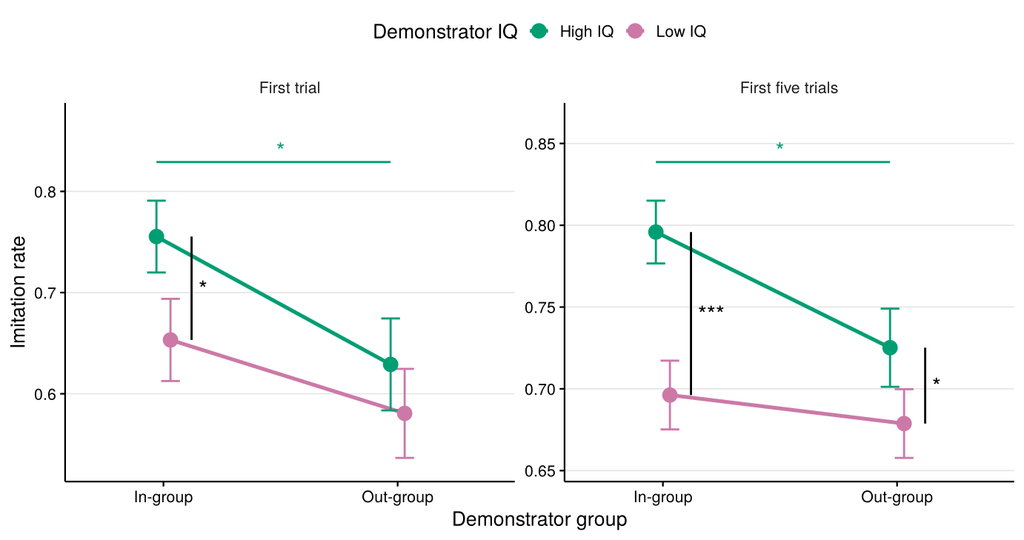

```r
# vertical space of each panel, used to place the brackets
imitation_window_range <- imitation_window_summary %>%
  group_by(trial_window) %>%
  summarise(top = max(mean + sem), span = max(mean + sem) - min(mean - sem), .groups = "drop")

# horizontal brackets: in vs. out within each IQ level (only significant tests)
imitation_group_significance <- imitation_group_tests %>%
  filter(p_wilcox < .05) %>%
  left_join(imitation_window_range, by = "trial_window") %>%
  mutate(x     = 1 + ifelse(iq == "high", -0.03, 0.03),
         xend  = 2 + ifelse(iq == "high", -0.03, 0.03),
         y     = top + span * ifelse(iq == "high", 0.15, 0.35),
         label = case_when(p_wilcox < .001 ~ "***", p_wilcox < .01 ~ "**", TRUE ~ "*"))

# vertical bars: high vs. low IQ within each group (only significant tests)
imitation_iq_significance <- imitation_iq_tests %>%
  filter(p_wilcox < .05) %>%
  left_join(imitation_window_summary %>%
              select(trial_window, grouping, iq, mean) %>%
              pivot_wider(names_from = iq, values_from = mean, names_prefix = "plot_mean_"),
            by = c("trial_window", "grouping")) %>%
  mutate(x     = as.numeric(grouping) + 0.12,
         label = case_when(p_wilcox < .001 ~ "***", p_wilcox < .01 ~ "**", TRUE ~ "*"))

fig_imitation_conditions <- ggplot(imitation_window_summary, aes(x = x_pos, y = mean, colour = iq, group = iq)) +
  geom_line(linewidth = 0.9) +
  geom_errorbar(aes(ymin = mean - sem, ymax = mean + sem), width = 0.08, linewidth = 0.5) +
  geom_point(size = 3) +
  geom_segment(data = imitation_group_significance, aes(x = x, xend = xend, y = y, yend = y, colour = iq),
               inherit.aes = FALSE, linewidth = 0.5, show.legend = FALSE) +
  geom_text(data = imitation_group_significance, aes(x = 1.5, y = y, label = label, colour = iq),
            inherit.aes = FALSE, vjust = -0.2, size = 4, show.legend = FALSE) +
  geom_segment(data = imitation_iq_significance, aes(x = x, xend = x, y = plot_mean_high, yend = plot_mean_low),
               inherit.aes = FALSE, linewidth = 0.5) +
  geom_text(data = imitation_iq_significance, aes(x = x + 0.03, y = (plot_mean_high + plot_mean_low) / 2, label = label),
            inherit.aes = FALSE, hjust = 0, size = 4) +
  facet_wrap(~ trial_window, scales = "free_y") +
  scale_x_continuous(breaks = 1:2, labels = label_grouping[c("in", "out")], expand = expansion(add = 0.35)) +
  scale_y_continuous(expand = expansion(mult = c(0.08, 0.2))) +
  scale_colour_manual(values = colour_iq, labels = label_iq, name = "Demonstrator IQ") +
  labs(x = "Demonstrator group", y = "Imitation rate") +
  theme(panel.grid.major.y = element_line(colour = "grey90", linewidth = 0.3))

fig_imitation_conditions
```

```r
ggsave(file.path(output_dir, "imitation_conditions.png"), fig_imitation_conditions,
       width = 183, height = 95, units = "mm", dpi = 300)
```

# 12. Reaction time

## 12.1 Interaction plot: choice and prediction RT by condition

All recorded RTs are used, without a time-based exclusion. Each participant’s RTs are averaged within each condition, separately for the choice and the prediction phase. The plot shows the mean of these participant values with ± 1 SEM error bars. Both phases are saved as one image.

Simple effects are tested and drawn in the same way as in 11.1: paired Wilcoxon signed-rank tests, no correction for multiple comparisons, and only significant comparisons drawn (* p < .05, ** p < .01, *** p < .001).

- in-group vs. out-group within each IQ level: coloured horizontal bracket above the panel (colour = IQ level);
- high vs. low IQ within each group: black vertical bar to the right of that group’s two points.

```r
rt_condition_cells <- trial_data %>%
  pivot_longer(c(choice_rt, pred_rt), names_to = "task_phase", values_to = "rt") %>%
  filter(!is.na(rt)) %>%
  mutate(task_phase = factor(ifelse(task_phase == "choice_rt", "Choice", "Prediction"), levels = c("Choice", "Prediction"))) %>%
  group_by(task_phase, participant, grouping, iq) %>%
  summarise(rt = mean(rt), .groups = "drop")

rt_condition_summary <- rt_condition_cells %>%
  group_by(task_phase, grouping, iq) %>%
  summarise(n = n(), mean = mean(rt), sd = sd(rt), .groups = "drop") %>%
  mutate(sem   = sd / sqrt(n),
         x_pos = as.numeric(grouping) + ifelse(iq == "high", -0.03, 0.03))

rt_condition_summary %>% mutate(across(where(is.numeric), ~ round(.x, 1)))
```

```
## # A tibble: 8 x 8
##   task_phase grouping iq        n  mean    sd   sem x_pos
##   <fct>      <fct>    <fct> <dbl> <dbl> <dbl> <dbl> <dbl>
## 1 Choice     in       high     62  670   178.  22.6     1
## 2 Choice     in       low      62  668.  167.  21.2     1
## 3 Choice     out      high     62  675.  158.  20.1     2
## 4 Choice     out      low      62  679.  176.  22.4     2
## 5 Prediction in       high     62  809.  212.  27       1
## 6 Prediction in       low      62  801   192.  24.4     1
## 7 Prediction out      high     62  816.  208.  26.5     2
## 8 Prediction out      low      62  822.  190.  24.2     2
```

```r
# in-group vs. out-group within each IQ level
rt_group_tests <- rt_condition_cells %>%
  pivot_wider(names_from = grouping, values_from = rt) %>%
  filter(!is.na(`in`), !is.na(out)) %>%
  group_by(task_phase, iq) %>%
  summarise(n        = n(),
            mean_in  = mean(`in`),
            mean_out = mean(out),
            V        = unname(wilcox.test(`in`, out, paired = TRUE)$statistic),
            p_wilcox = wilcox.test(`in`, out, paired = TRUE)$p.value,
            .groups = "drop")

# high vs. low IQ within each group
rt_iq_tests <- rt_condition_cells %>%
  pivot_wider(names_from = iq, values_from = rt) %>%
  filter(!is.na(high), !is.na(low)) %>%
  group_by(task_phase, grouping) %>%
  summarise(n         = n(),
            mean_high = mean(high),
            mean_low  = mean(low),
            V         = unname(wilcox.test(high, low, paired = TRUE)$statistic),
            p_wilcox  = wilcox.test(high, low, paired = TRUE)$p.value,
            .groups = "drop")

rt_group_tests %>% mutate(p_wilcox = scales::pvalue(p_wilcox, accuracy = 0.001), across(where(is.numeric), ~ round(.x, 3)))
```

```
## # A tibble: 4 x 7
##   task_phase iq        n mean_in mean_out     V p_wilcox
##   <fct>      <fct> <dbl>   <dbl>    <dbl> <dbl> <chr>
## 1 Choice     high     62    670.     675.  813  0.253
## 2 Choice     low      62    668.     679.  844. 0.357
## 3 Prediction high     62    809.     816.  959  0.905
## 4 Prediction low      62    801.     822.  752  0.116
```

```r
rt_iq_tests %>% mutate(p_wilcox = scales::pvalue(p_wilcox, accuracy = 0.001), across(where(is.numeric), ~ round(.x, 3)))
```

```
## # A tibble: 4 x 7
##   task_phase grouping     n mean_high mean_low     V p_wilcox
##   <fct>      <fct>    <dbl>     <dbl>    <dbl> <dbl> <chr>
## 1 Choice     in          62      670.     668.  1030 0.710
## 2 Choice     out         62      675.     679.   931 0.752
## 3 Prediction in          62      809.     801.  1110 0.351
## 4 Prediction out         62      816.     822.   963 0.927
```

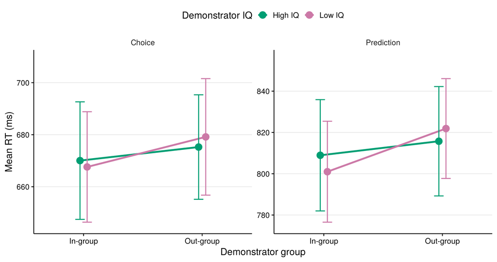

```r
# vertical space of each panel, used to place the brackets
rt_phase_range <- rt_condition_summary %>%
  group_by(task_phase) %>%
  summarise(top = max(mean + sem), span = max(mean + sem) - min(mean - sem), .groups = "drop")

# horizontal brackets: in vs. out within each IQ level (only significant tests)
rt_group_significance <- rt_group_tests %>%
  filter(p_wilcox < .05) %>%
  left_join(rt_phase_range, by = "task_phase") %>%
  mutate(x     = 1 + ifelse(iq == "high", -0.03, 0.03),
         xend  = 2 + ifelse(iq == "high", -0.03, 0.03),
         y     = top + span * ifelse(iq == "high", 0.15, 0.35),
         label = case_when(p_wilcox < .001 ~ "***", p_wilcox < .01 ~ "**", TRUE ~ "*"))

# vertical bars: high vs. low IQ within each group (only significant tests)
rt_iq_significance <- rt_iq_tests %>%
  filter(p_wilcox < .05) %>%
  left_join(rt_condition_summary %>%
              select(task_phase, grouping, iq, mean) %>%
              pivot_wider(names_from = iq, values_from = mean, names_prefix = "plot_mean_"),
            by = c("task_phase", "grouping")) %>%
  mutate(x     = as.numeric(grouping) + 0.12,
         label = case_when(p_wilcox < .001 ~ "***", p_wilcox < .01 ~ "**", TRUE ~ "*"))

fig_reaction_time <- ggplot(rt_condition_summary, aes(x = x_pos, y = mean, colour = iq, group = iq)) +
  geom_line(linewidth = 0.9) +
  geom_errorbar(aes(ymin = mean - sem, ymax = mean + sem), width = 0.08, linewidth = 0.5) +
  geom_point(size = 3) +
  geom_segment(data = rt_group_significance, aes(x = x, xend = xend, y = y, yend = y, colour = iq),
               inherit.aes = FALSE, linewidth = 0.5, show.legend = FALSE) +
  geom_text(data = rt_group_significance, aes(x = 1.5, y = y, label = label, colour = iq),
            inherit.aes = FALSE, vjust = -0.2, size = 4, show.legend = FALSE) +
  geom_segment(data = rt_iq_significance, aes(x = x, xend = x, y = plot_mean_high, yend = plot_mean_low),
               inherit.aes = FALSE, linewidth = 0.5) +
  geom_text(data = rt_iq_significance, aes(x = x + 0.03, y = (plot_mean_high + plot_mean_low) / 2, label = label),
            inherit.aes = FALSE, hjust = 0, size = 4) +
  facet_wrap(~ task_phase, scales = "free_y") +
  scale_x_continuous(breaks = 1:2, labels = label_grouping[c("in", "out")], expand = expansion(add = 0.35)) +
  scale_y_continuous(expand = expansion(mult = c(0.08, 0.2))) +
  scale_colour_manual(values = colour_iq, labels = label_iq, name = "Demonstrator IQ") +
  labs(x = "Demonstrator group", y = "Mean RT (ms)") +
  theme(panel.grid.major.y = element_line(colour = "grey90", linewidth = 0.3))

fig_reaction_time
```

```r
ggsave(file.path(output_dir, "reaction_time.png"), fig_reaction_time,
       width = 183, height = 95, units = "mm", dpi = 300)
```